# Analysis of Song Lyrics and Newspaper Headlines

## Word Cloud of Song Titles (All Years)

### A word cloud of the most frequently used words in song titles for the entire Million Songs subset. From the graphic, we can see that 'you', 'love', and 'live' are some of the most popular words used.

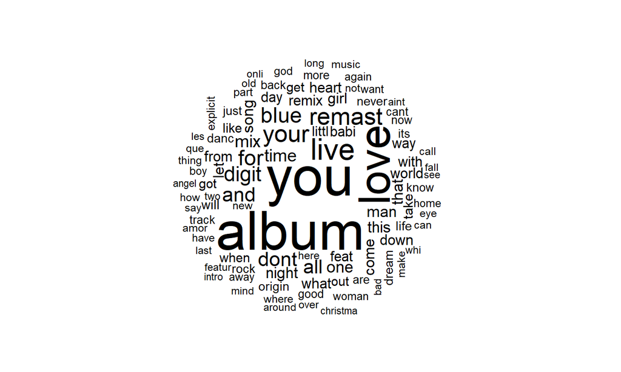

## #Word Cloud of NYT Headlines (1996-present)

### A word cloud of the most frequently used words in NY Times headlines from 1996 to the present. From the graphic, we can see that 'new', 'bush', and 'war' are some of the most popular words used.

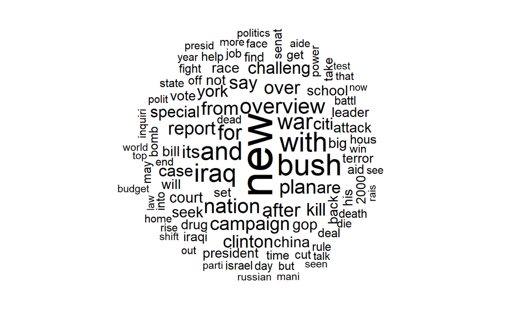

## #Artist Year and Album Title (1996-present)

### A word cloud of the most frequently used words in Album Titles for the years 1996 to the present for the Million Songs subset. From the graphic, we can see that 'love' and 'live' continue to be some of the most popular words used.

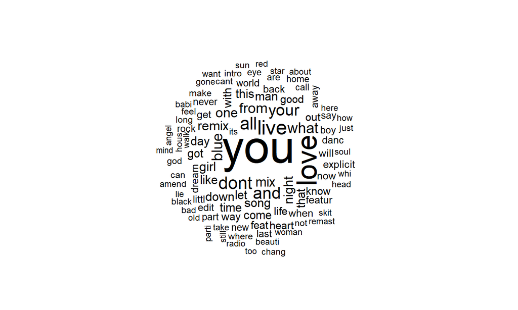